# 230424_review_rc_datasets

PR

2023-04-24

## Goals

There are a lot of RC datasets out there, and it’s hard to keep them straight. We are specifically interested in Wenas Creek as our fire-impacted watershed. The goals here are:

1. review what datasets are published, and what they contain
2. review what datasets are in prep and what they contain and
3. explore what datasets are most useful.

### Background on data packages

In trying to keep this copacetic, I’m only using data published on ESS-DIVE.

### SS21 - RC2 Spatial study 2021

We have single measurements available for W10 and W20 from SS21, data types include Manta, MiniDots, and grab samples.

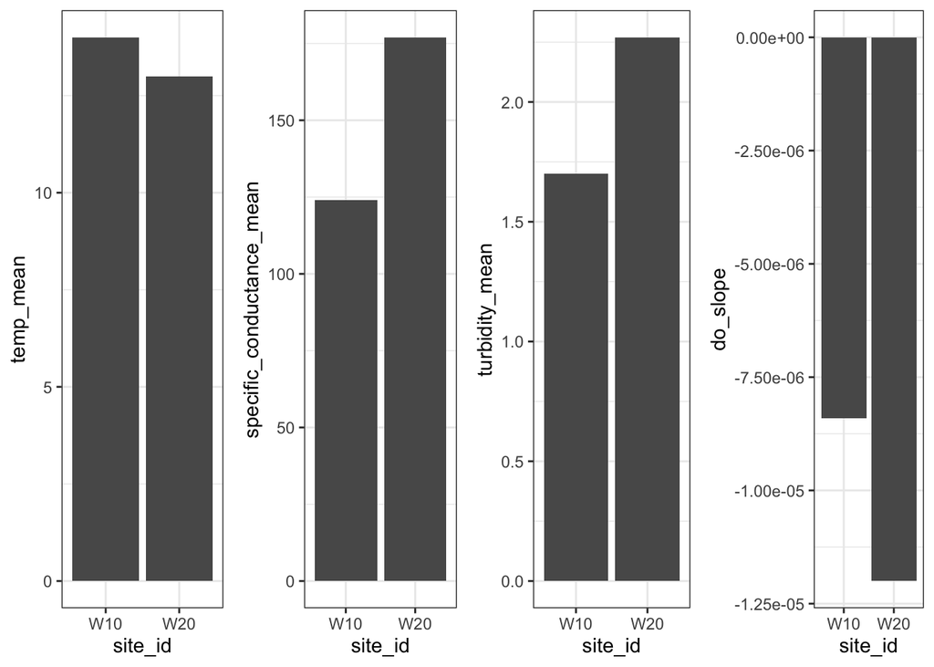

### TS21 - RC2 Temporal study 2021

It doesn’t look like Wenas was sampled, **Is that right??**

### SS22 - Spatial study 2022

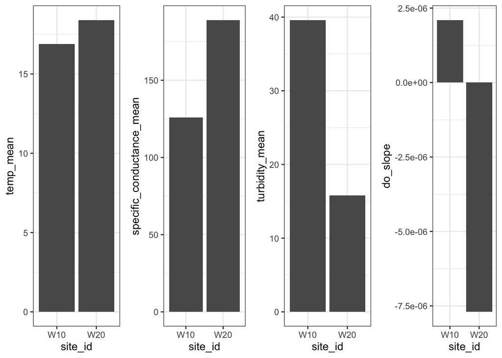

### Coming soon

#### RC2 SS22 MiniDot respiration datasets for 1 month

#### RC3 2021-2022 (1+ yr!) grab sampling

collected monthly, grab samples and sensors (Manta, YSI handheld, Ultrameter - no respiration)

#### Left Mantas out through SS22 (maybe a month of data?)

#### Random fire info

2022 - Evans Canyon Fire - Both W10 and W20 burned

### Other info informing our assumptions

#### How many samples?

- 1 - per AMP
- 2 times min - deploy & retrieve
- 3 times potentially? - deploy, maintain, retrieve (cotton strips might not last a month)

### What data do we need, and why

- In-situ respiration for as long as possible (Minidot, Barotroll and HOBO) - probably entails a wading transect
- TSS - large change between 21/22 - linked to respiration? (no clear companion analyses)
- DOC/TDN (OCN) - two birds (C and N) w one analytical stone

### Other thoughts:

- plenty of reaches, including FT, CDOM, Ions, lab respiration (but would be a pain), but above are essentials
- CAVEAT: Don’t know what 2021 respiration time-series look like, hard to guess what’s important without seeing prior data!